# Week10Submit

##### **CSPB 4830 - Special Topics: Coding Calculus**

### **Week #10 Workbook**

**Stephen Enriquez (@sten8791)**

### Activity #1

Code RIEMANN, p.362, 3 versions, for left hand, right hand, midpoint sums. Include a graphics option of drawing the boxes - make sure you can toggle this on/off. Add a feature to adjust the number of boxes shown.

```python
"""
Calculates Riemann sums for a given interval. Calls the following parameters:
    - func: The function f(x) to evaluate
    - a: The start of the interval for calculations
    - b: The end of the interval for calculations
    - num_steps: The number of intervals between a and b.
    - sampling_point: Either "left", "mid", or "right" sampling point from 'x' to 'x + delta_x'.
    - show_table: Print results in tabulated form.
    - show_plot: Show boxes.
"""
def riemann_sums(func, a, b, num_steps, sampling_point, show_table=0, show_plot=0, pass_values=0):
    from tabulate import tabulate
    import matplotlib.pyplot as plt
    import numpy as np

    delta_x = (b - a)/num_steps

    # adjust starting sampling point based on delta_x
    if sampling_point == "left":
            x = a
            label_ ="Left endpoint"
    if sampling_point == "mid":
            x = a + delta_x/2
            label_ ="Midpoint"
    if sampling_point == "right":
            x = a + delta_x
            label_ ="Right endpoint"

    # initialize lists to track values for display
    accumulation_vals = []
    delta_S_vals = []
    x_vals = []
    f_x_vals = []

    accumulation = 0
    for k in range(1, num_steps+1):
        x_vals.append(x)
        f_x_vals.append(func(x))

        delta_S = func(x) * delta_x
        accumulation = accumulation + delta_S
        x = x + delta_x

        delta_S_vals.append(delta_S)
        accumulation_vals.append(accumulation)

    sum_final = accumulation_vals[-1]

    # show full table
    if show_table == 1:
        table_ = zip(x_vals, f_x_vals, delta_S_vals, accumulation_vals)
        tbl_headers_=[f"{label_}", "current f(x)", "current delta_S", "accumulated S"]
        print(tabulate((table_), headers=tbl_headers_, colalign=("left","left","left","left")))

    # show truncated table (only last 5 rows) for really small interval sizes
    if show_table == 2:
        table_ = zip(x_vals[-5:], f_x_vals[-5:], delta_S_vals[-5:], accumulation_vals[-5:])
        tbl_headers_=[f"{label_}", "current f(x)", "current delta_S", "accumulated S"]
        print("From last five delta_x intervals:")
        print(tabulate((table_), headers=tbl_headers_, colalign=("left","left","left","left")))

    # show boxes
    if show_plot == 1:
        # generate intervals for plotting f(x)
        intervals_ = np.arange(a, b+delta_x, delta_x)
        f_x_plot = []
        for x in intervals_:
            f_x_plot.append(func(x))

        fig, ax = plt.subplots()
        if sampling_point == "mid":
            x_vals = [x - delta_x/2 for x in x_vals]
        if sampling_point == "right":
            #x_vals = [x for x in x_vals]
            x_vals = [x - delta_x for x in x_vals]
        plt.plot(intervals_, f_x_plot, label = "f(x)", color='red', zorder = 2)
        plt.bar(x_vals, f_x_vals, width=delta_x, align="edge",
                color='orange', edgecolor="black", alpha=0.5, zorder = 1)
        plt.title(f"{label_} sum over [{a},{b}] = {sum_final}\n")
        plt.legend()
        plt.xlabel("x")
        plt.ylabel("Sum")

    # we return the x and y arrays so we can call this in our plot_multi function
    if pass_values==1:
        return x_vals, f_x_vals
    if pass_values==2:
         return accumulation_vals[-1]
    else:
        print(f"{label_} Riemann sum over interval [{a},{b}] = {accumulation_vals[-1]}\n")
        return
```

```python
def func(x):
    import math
    return math.sqrt(1 + x**3)
```

```
Right endpoint    current f(x)    current delta_S    accumulated S
----------------  --------------  -----------------  ---------------
1.5               2.09165         1.04583            1.04583
2                 3               1.5                2.54583
2.5               4.07738         2.03869            4.58451
3                 5.2915          2.64575            7.23026
Right endpoint Riemann sum over interval [1,3] = 7.230264648019697
```

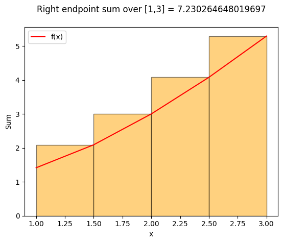

```python
riemann_sums(func, 1, 3, 4, "right", 1, 1)
```

As we can see in the plot above, we are correctly sampling at the right endpoint of each interval for f(x).

### Activity #2

For each of the 3 versions of RIEMANN, create a single "hero" graphic that illustrates the differences between the 3 methods.

For this activity, I decided to see what it would look like if we plotted the "left endpoint", "midpoint" and "right endpoint" Riemann calculations on the same plot.

```python
def plot_multi(func, a, b, num_steps):
        import matplotlib.pyplot as plt
        import numpy as np
        x_vals_left, y_left = riemann_sums(func, a, b, num_steps, "left", 0, 0, 1)
        x_vals_mid, y_mid = riemann_sums(func, a, b, num_steps, "mid", 0, 0, 1)
        x_vals_right, y_right= riemann_sums(func, a, b, num_steps, "right", 0, 0, 1)

        delta_x = (b - a)/num_steps
        # generate lists for plotting f(x)
        intervals_ = np.arange(a, b+delta_x, delta_x)
        f_x_plot = []
        for x in intervals_:
                f_x_plot.append(func(x))

        # adjust x-values for plotting boxes
        x_vals_mid = [x - delta_x/2 for x in x_vals_mid]
        x_vals_right = [x - delta_x for x in x_vals_right]

        sum_left = round(y_left[-1],2)
        sum_mid = round(y_mid[-1],2)
        sum_right = round(y_right[-1],2)

        plt.bar(x_vals_left, y_left, width=delta_x, align="edge", color='blue',
                edgecolor="black", alpha=0.4, label=f"Left Endpoint Sum = {sum_left}", zorder=3)
        plt.bar(x_vals_mid, y_mid, width=delta_x, align="edge", color='green',
                edgecolor="black", alpha=0.4, label=f"Mid Endpoint Sum = {sum_mid}", zorder=2)
        plt.bar(x_vals_right, y_right, width=delta_x, align="edge", color='yellow',
                edgecolor="black", alpha=0.4, label=f"Right Endpoint Sum = {sum_right}", zorder=1)
        plt.plot(intervals_, f_x_plot, label = "f(x)", zorder = 4, color = "red")

        plt.xlabel("x")
        plt.ylabel("Sum")
        plt.title(f"Riemann sum comparisons")
        plt.legend()
        plt.show()
```

Let's demonstrate this with a sample functions below:

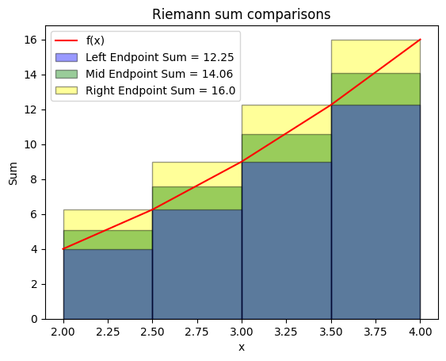

```python
def x_square(x):
    return x ** 2

plot_multi(x_square, 2, 4, 4)
```

We are able to show with the above graphic how each endpoint is selected from each subinterval. Each subinterval has size delta_x = 0.50.

Looking at the first subinterval above [2.0, 2.5]:

- the left endpoint "box" samples at the left endpoint value of f(x) at x = 2.0
- the midpoint "box" samples at the midpoint value of f(x) at x = 2.25
- the right endpoint "box" correctly samples at the right endpoint value of f(x) at x = 2.50

The above plot demonstrates how each method differs from each other.

Let's look at another function below:

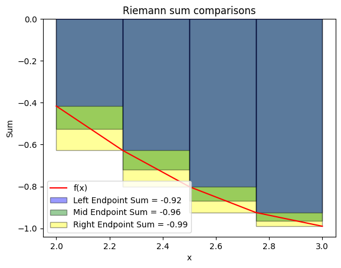

```python
def cosine(x):
    import math
    return math.cos(x)

plot_multi(cosine, 2, 3, 4)
```

As we observe, even if f(x) results in negative values, we still correctly sample at each endpoint as specified.

### Activity #3

Experiment with questions 4 - 12 on pages 366 - 368, either or on your own, coding as much or as little as you need to show the point. Once you have the code this should be pretty quick. Add a summary of the advantages and disadvantages of the three methods.

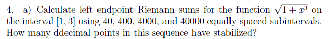

We can call our riemann_sums() function with the given parameters:

```python
def func_1(x):
    import math
    return math.sqrt(1 + x**3)
```

```
From last five delta_x intervals:
Left endpoint    current f(x)    current delta_S    accumulated S
---------------  --------------  -----------------  ---------------
2.75             4.66871         0.233436           5.13792
2.8              4.79082         0.239541           5.37746
2.85             4.91418         0.245709           5.62317
2.9              5.03875         0.251937           5.87511
2.95             5.16453         0.258227           6.13334
Left endpoint Riemann sum over interval [1,3] = 6.133337696563011
```

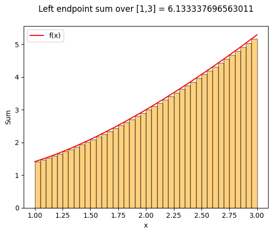

```python
riemann_sums(func_1, 1, 3, 40, "left", 2, 1)
```

```python
riemann_sums(func_1, 1, 3, 400, "left", 2, 0)
```

```
From last five delta_x intervals:
Left endpoint    current f(x)    current delta_S    accumulated S
---------------  --------------  -----------------  ---------------
2.975            5.22787         0.0261393          6.11508
2.98             5.24057         0.0262029          6.14128
2.985            5.25329         0.0262664          6.16755
2.99             5.26601         0.0263301          6.19388
2.995            5.27875         0.0263938          6.22027
Left endpoint Riemann sum over interval [1,3] = 6.220269270650224
```

```python
riemann_sums(func_1, 1, 3, 4000, "left", 2, 0)
```

```
From last five delta_x intervals:
Left endpoint    current f(x)    current delta_S    accumulated S
---------------  --------------  -----------------  ---------------
2.9975           5.28513         0.00264256         6.21841
2.998            5.2864          0.0026432          6.22106
2.9985           5.28768         0.00264384         6.2237
2.999            5.28895         0.00264448         6.22634
2.9995           5.29023         0.00264511         6.22899
Left endpoint Riemann sum over interval [1,3] = 6.228990096672928
```

```python
riemann_sums(func_1, 1, 3, 40000, "left", 2, 0)
```

[output not shown]

When evaluating the sum all the way to 40000 equally-spaced subintervals, it appears that 2 decimal points in this sequence have definitely stabilized, although a case can be made for the sum stabilizing closer to '6.229'.

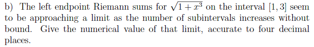

Let's examine the sum calculations over really large number of subintervals by evaluating the sums for subintervals of 40000, 400000, and 4000000.

```python
riemann_sums(func_1, 1, 3, 40000, "left", 2)
```

```
From last five delta_x intervals:
Left endpoint    current f(x)    current delta_S    accumulated S
---------------  --------------  -----------------  ---------------
2.99975          5.29086         0.000264543        6.2288
2.9998           5.29099         0.00026455         6.22907
2.99985          5.29112         0.000264556        6.22933
2.9999           5.29125         0.000264562        6.2296
2.99995          5.29138         0.000264569        6.22986
Left endpoint Riemann sum over interval [1,3] = 6.229862455971611
```

```python
riemann_sums(func_1, 1, 3, 400000, "left", 2)
```

```
From last five delta_x intervals:
Left endpoint    current f(x)    current delta_S    accumulated S
---------------  --------------  -----------------  ---------------
2.99997          5.29144         2.64572e-05        6.22984
2.99998          5.29145         2.64573e-05        6.22987
2.99998          5.29146         2.64573e-05        6.2299
2.99999          5.29148         2.64574e-05        6.22992
2.99999          5.29149         2.64574e-05        6.22995
Left endpoint Riemann sum over interval [1,3] = 6.2299496946396795
```

```python
riemann_sums(func_1, 1, 3, 4000000, "left", 2)
```

```
From last five delta_x intervals:
Left endpoint    current f(x)    current delta_S    accumulated S
---------------  --------------  -----------------  ---------------
3                5.2915          2.64575e-06        6.22995
3                5.2915          2.64575e-06        6.22995
3                5.2915          2.64575e-06        6.22995
3                5.2915          2.64575e-06        6.22996
3                5.2915          2.64575e-06        6.22996
Left endpoint Riemann sum over interval [1,3] = 6.229958419169753
```

```python
riemann_sums(func_1, 1, 3, 40000000, "left", 2)
```

```
From last five delta_x intervals:
Left endpoint    current f(x)    current delta_S    accumulated S
---------------  --------------  -----------------  ---------------
3                5.2915          2.64575e-07        6.22996
3                5.2915          2.64575e-07        6.22996
3                5.2915          2.64575e-07        6.22996
3                5.2915          2.64575e-07        6.22996
3                5.2915          2.64575e-07        6.22996
Left endpoint Riemann sum over interval [1,3] = 6.229959289118588
```

The limit that we are approaching appears to be '6.2299' as we approach 4,000,000 subintervals.

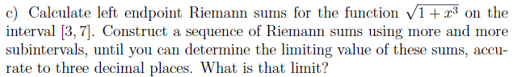

Let's examine what the Riemann sums evaluate to over 1000, 10000, 100000, and 1000000 subintervals:

```python
riemann_sums(func_1, 3, 7, 1000, "left")
```

```
Left endpoint Riemann sum over interval [3,7] = 45.79350212926619
```

```python
riemann_sums(func_1, 3, 7, 10000, "left")
```

```
Left endpoint Riemann sum over interval [3,7] = 45.817360587824595
```

```python
riemann_sums(func_1, 3, 7, 100000, "left")
```

```
Left endpoint Riemann sum over interval [3,7] = 45.81974660143459
```

```python
riemann_sums(func_1, 3, 7, 1000000, "left")
```

```
Left endpoint Riemann sum over interval [3,7] = 45.81998520340121
```

The limiting value of these sums over the interval [3,7] , accurate to three decimal places, appears to be '45.819'.

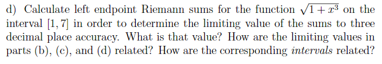

```python
riemann_sums(func_1, 1, 7, 100000, "left", 2)
```

```
From last five delta_x intervals:
Left endpoint    current f(x)    current delta_S    accumulated S
---------------  --------------  -----------------  ---------------
6.9997           18.546          0.00111276         52.045
6.99976          18.5463         0.00111278         52.0461
6.99982          18.5465         0.00111279         52.0472
6.99988          18.5468         0.00111281         52.0483
6.99994          18.547          0.00111282         52.0495
Left endpoint Riemann sum over interval [1,7] = 52.04945711400325
```

```python
riemann_sums(func_1, 1, 7, 1000000, "left", 2)
```

```
From last five delta_x intervals:
Left endpoint    current f(x)    current delta_S    accumulated S
---------------  --------------  -----------------  ---------------
6.99997          18.5471         0.000111283        52.0495
6.99998          18.5471         0.000111283        52.0496
6.99998          18.5472         0.000111283        52.0497
6.99999          18.5472         0.000111283        52.0498
6.99999          18.5472         0.000111283        52.0499
Left endpoint Riemann sum over interval [1,7] = 52.04991970421313
```

The limiting value of the sums over the interval [1,7] to three decimal place accuracy is '52.049'

From part b), the sum over interval [1,3] is: 6.2299 From part c), the sum over interval [3,7] is: 45.8199

Since we are evaluating the same function which is continuous over the interval [1,7], it should follow that the sums for sub-intervals [1,3] and [3,7] should sum up to the sum over the entire interval [1,7].

As we can check,

6.2299 + 45.8199 = 52.0498

Which confirms that the sum over the entire interval is equal to the sums over its sub-intervals.

Let's demonstrate this by plotting the boxes representing the sums for interval [1,3] and the sums for interval [3,7]:

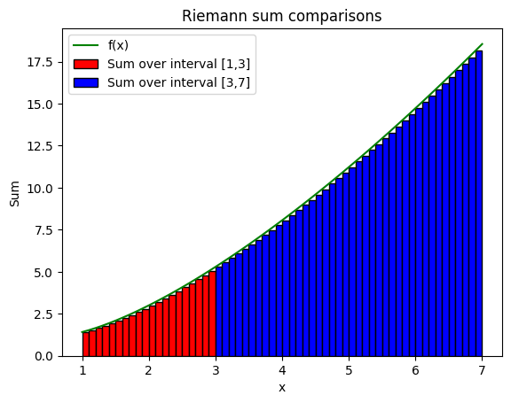

```python
x_vals_left1, y_left1 = riemann_sums(func, 1, 3, 20, "left", 0, 0, 1)
x_vals_left2, y_left2 = riemann_sums(func, 3, 7, 40, "left", 0, 0, 1)
import matplotlib.pyplot as plt
import numpy as np
delta_x = .1

intervals_ = np.arange(1, 7+delta_x, delta_x)
f_x_plot = []
for x in intervals_:
        f_x_plot.append(func(x))

plt.bar(x_vals_left1, y_left1, width=delta_x, align="edge", color='red',
        edgecolor="black", alpha=1, label=f"Sum over interval [1,3]", zorder=3)
plt.bar(x_vals_left2, y_left2, width=delta_x, align="edge", color='blue',
        edgecolor="black", alpha=1, label=f"Sum over interval [3,7]", zorder=3)
plt.plot(intervals_, f_x_plot, label = "f(x)", zorder = 4, color = "green")

plt.xlabel("x")
plt.ylabel("Sum")
plt.title(f"Riemann sum comparisons")
plt.legend()
plt.show()
```

When put together, this combined plot looks exactly like the plot below representing the sums over the entire interval of [1,7]:

```
Left endpoint Riemann sum over interval [1,7] = 51.53685104402981
```

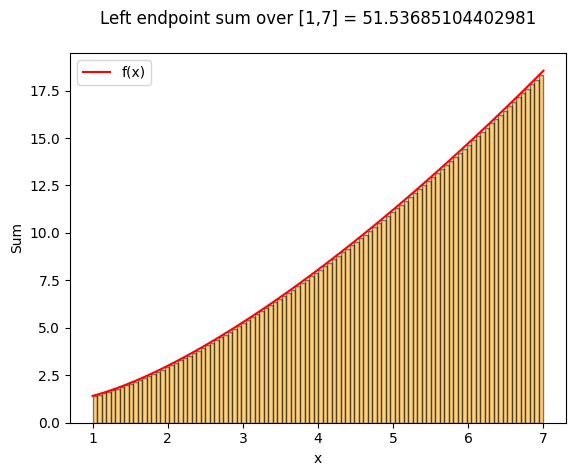

```python
riemann_sums(func_1, 1, 7, 100, "left", 0, 1)
```

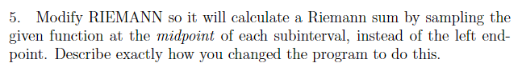

We accomplished this by adjusting the starting "endpoint". In order to sample at the midpoints, we must start at the midpoint of the first subinterval. Since the subinterval is ∆x units wide, its midpoint is ∆x/2 units from the left endpoint, which is x = a.

Thus we add the following line into our riemann_sum() function to set x = a + delta_x/2 :

```python
# adjust starting sampling point based on delta_x
# if sampling_point == "mid":
#        x = a + delta_x/2
#        label_ ="Midpoint"
```

We can visually verify this by plotting our Riemann sum calculation using the midpoint:

```
Midpoint Riemann sum over interval [1,7] = 51.98233367562983
```

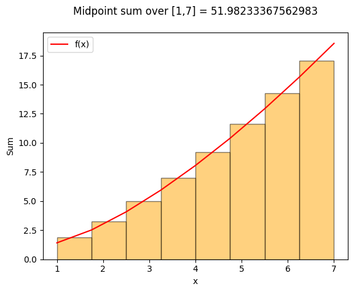

```python
riemann_sums(func_1, 1, 7, 8, "mid", 0, 1)
```

As we can visually confirm above, we are sampling at the midpoint of each interval.

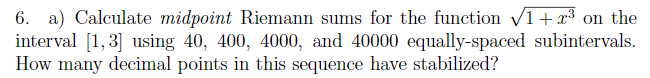

```python
riemann_sums(func_1, 1, 3, 40, "mid")
```

```
Midpoint Riemann sum over interval [1,3] = 6.229804122734282
```

```python
riemann_sums(func_1, 1, 3, 400, "mid")
```

```
Midpoint Riemann sum over interval [1,3] = 6.229957835175769
```

```python
riemann_sums(func_1, 1, 3, 4000, "mid")
```

```
Midpoint Riemann sum over interval [1,3] = 6.229959372356611
```

```python
riemann_sums(func_1, 1, 3, 40000, "mid")
```

```
Midpoint Riemann sum over interval [1,3] = 6.229959387732263
```

From our calculations above, it appears that up to 7 decimal points in this sequence have stabilized at 40,000 equally-spaced subintervals. Although it is surprising how quickly the sums have stabilized even at lower number of intervals.

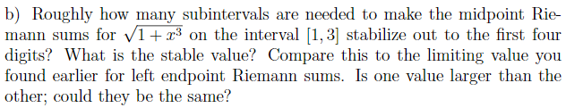

From part a, it's clear that at 400 subintervals, the sums have stabilized out to the first four digits at **6.2299**. Let's see if it stabilizes at fewer subintervals than 400:

```python
riemann_sums(func_1, 1, 3, 60, "mid")
```

```
Midpoint Riemann sum over interval [1,3] = 6.229890379745923
```

```python
riemann_sums(func_1, 1, 3, 80, "mid")
```

```
Midpoint Riemann sum over interval [1,3] = 6.229920570529844
```

It looks like roughly **80** subintervals are needed to make the midpoint sums stabilize out to the first for digits.

Comparing this to the limiting value found earlier for left endpoint Riemann sums:

Left endpoint Riemann sum over interval [1,3] = 6.229959289118588

The limiting value for the midpoint Riemann sum over the same interval looks to be **the same** to the limiting value we found earlier for the left endpoint Riemann sums.

However, if these sums are evaluated over a smaller number of subintervals, then these values could be different.

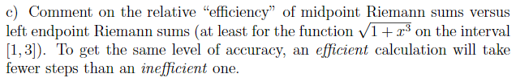

Based on our exploration in part b, the midpoint Riemann sums are way more efficient than the left endpoint Riemann sums.

The left endpoint Riemann sums in our previous example have not yet stabilized even at 100000 subintervals, whereas the midpoint Riemann sums above seem to stabilize even at 1000 subintervals.

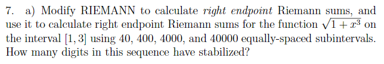

```python
riemann_sums(func_1, 1, 3, 40, "right")
```

```
Right endpoint Riemann sum over interval [1,3] = 6.327202149550815
```

```python
riemann_sums(func_1, 1, 3, 400, "right")
```

```
Right endpoint Riemann sum over interval [1,3] = 6.239655715949005
```

```python
riemann_sums(func_1, 1, 3, 4000, "right")
```

```
Right endpoint Riemann sum over interval [1,3] = 6.230928741202806
```

```python
riemann_sums(func_1, 1, 3, 40000, "right")
```

```
Right endpoint Riemann sum over interval [1,3] = 6.2300563204246
```

Only the first 2 digits appear to have stablized over the above sequence of subintervals.

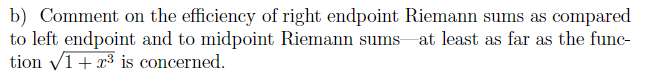

As we observe above, the right endpoint Riemann sums seems to require just as many subintervals (really high) to stabilize as the left endpoint Riemann sums. Both are inferior to the midpoint Riemann sum method which stabilizes even at smaller number of subintervals.

I would say that thee right endpoint and left endpoint Riemann sums are similarly inefficient compared to the midpoint Riemann sum.

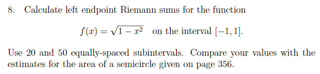

```python
def part8(x):
    import math
    return math.sqrt(1 - x**2)
```

```
Left endpoint Riemann sum over interval [-1,1] = 1.5522591631241593
```

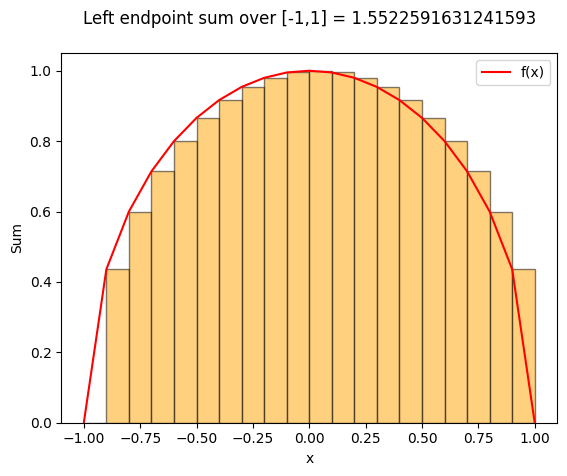

```python
riemann_sums(part8, -1, 1, 20, "left", 0, 1)
```

```python
riemann_sums(part8, -1, 1, 50, "left")
```

```
Left endpoint Riemann sum over interval [-1,1] = 1.5660981554514977
```

From page 356:

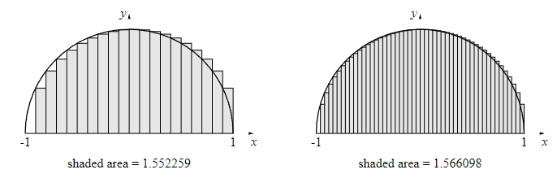

As we can see, the Riemann sum values we calculated above are the same as the above estimates for the area of a semicircle.

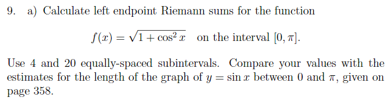

```
Left endpoint Riemann sum over interval [0,3.141592653589793] = 3.819943643179836
```

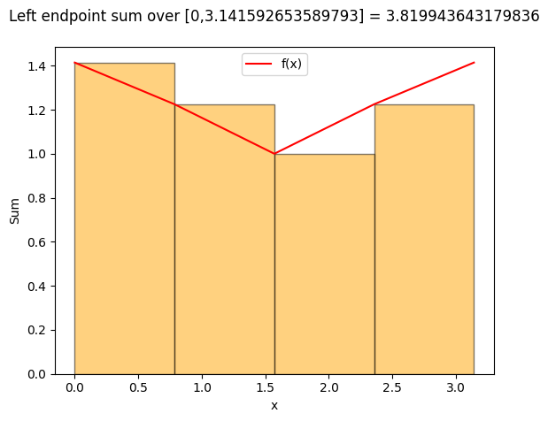

```python
def part9(x):
    import math
    return math.sqrt(1 + math.cos(x) ** 2)
import math
pi = math.pi

riemann_sums(part9, 0, pi, 4, "left", 0, 1)
```

```
Left endpoint Riemann sum over interval [0,3.141592653589793] = 3.820197789027713
```

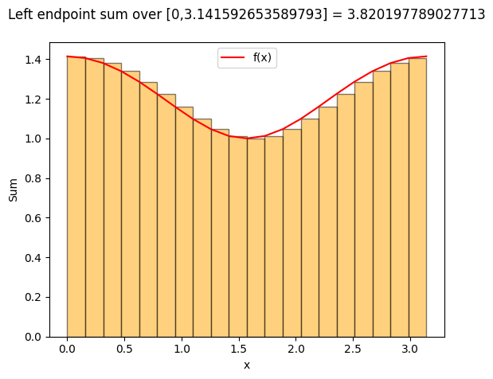

```python
riemann_sums(part9, 0, pi, 20, "left", 0, 1)
```

These Riemann sums are equivalent to the estimates for the length of the graph of y = sin x between 0 and π, given on page 358:

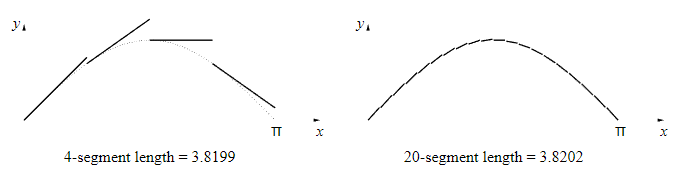

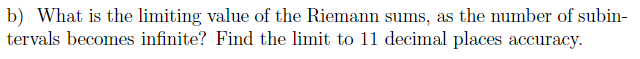

Let's explore how the sums stabilize as we increase the number of subintervals to evaluate:

```python
riemann_sums(part9, 0, pi, 10000, "left")
```

```
Left endpoint Riemann sum over interval [0,3.141592653589793] = 3.820197789027805
```

```python
riemann_sums(part9, 0, pi, 100000, "left")
```

```
Left endpoint Riemann sum over interval [0,3.141592653589793] = 3.8201977890282395
```

```python
riemann_sums(part9, 0, pi, 1000000, "left")
```

```
Left endpoint Riemann sum over interval [0,3.141592653589793] = 3.8201977890251326
```

Wtih 1,000,000 subintervals, the limiting value of the Riemann sums appears to be: **3.82019778902**

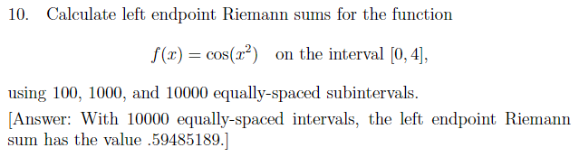

```python
def part10(x):
    import math
    return math.cos(x ** 2)
```

```python
riemann_sums(part10, 0, 4, 100, "left")
```

```
Left endpoint Riemann sum over interval [0,4] = 0.6339209745734815
```

```python
riemann_sums(part10, 0, 4, 1000, "left")
```

```
Left endpoint Riemann sum over interval [0,4] = 0.5983787174632444
```

```python
riemann_sums(part10, 0, 4, 10000, "left")
```

```
Left endpoint Riemann sum over interval [0,4] = 0.5948518901039331
```

We can confirm that with 10000 equally-spaced intervals, the left endpoint Riemannsum has the value of 0.59485189.

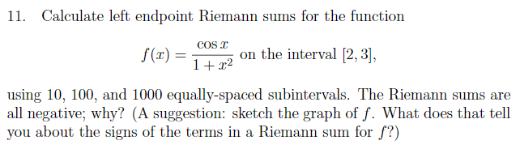

```python
def part11(x):
    import math
    return (math.cos(x)/(1 +x ** 2))
```

```
Left endpoint Riemann sum over interval [2,3] = -0.10320774749944361
```

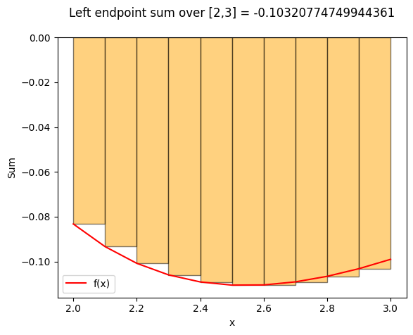

```python
riemann_sums(part11, 2, 3, 10, "left", 0, 1)
```

```
Left endpoint Riemann sum over interval [2,3] = -0.10404981921880206
```

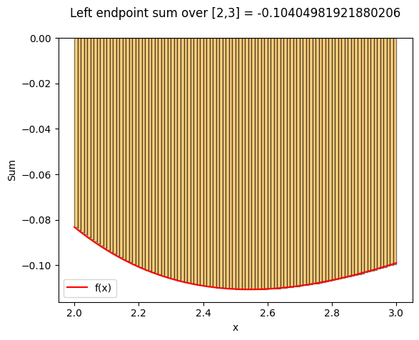

```python
riemann_sums(part11, 2, 3, 100, "left", 0, 1)
```

```python
riemann_sums(part11, 2, 3, 1000, "left")
```

```
Left endpoint Riemann sum over interval [2,3] = -0.10412210833479739
```

The Riemann sums are all negative because f(x) is negative between the interval of [2,3] as we can see in the plot of f(x) below:

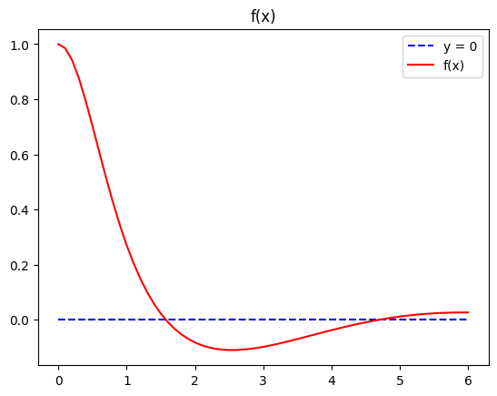

```python
def plot_function(func, a, b, num_steps):
        import matplotlib.pyplot as plt
        import numpy as np
        intervals_ = np.arange(a, b+delta_x, delta_x)
        f_x_plot = []
        for x in intervals_:
                f_x_plot.append(func(x))
        x_ = [intervals_[0], intervals_[-1]]
        plt.plot(x_, [0,0], label = "y = 0", linestyle='--', color = 'blue')
        plt.plot(intervals_, f_x_plot, label = "f(x)", color = "red")
        plt.title(f"f(x)")
        plt.legend()
        plt.show()

plot_function(part11,0,6,100)
```

If we stretch out the interval to include the section where f(x) is positive, then we arrive at a positive Riemann sum as shown below:

```
Left endpoint Riemann sum over interval [0,3] = 0.6793916661014973
```

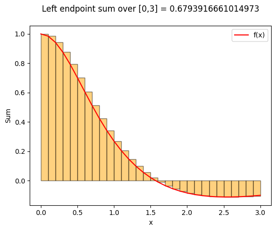

```python
riemann_sums(part11, 0, 3, 30, "left",0,1)
```

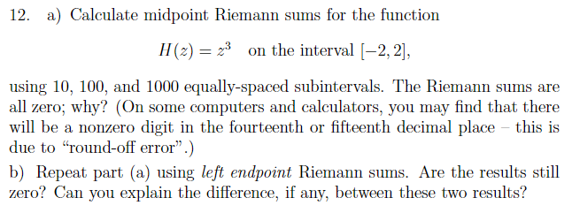

```python
def part12(x):
    return x ** 3

riemann_sums(part12, -2, 2, 10, "mid")
```

```
Midpoint Riemann sum over interval [-2,2] = 3.1086244689504383e-15
```

```python
riemann_sums(part12, -2, 2, 100, "mid")
```

```
Midpoint Riemann sum over interval [-2,2] = 2.020605904817785e-14
```

```python
riemann_sums(part12, -2, 2, 1000, "mid")
```

```
Midpoint Riemann sum over interval [-2,2] = 2.896988204881268e-14
```

As we can observe above, the Riemann sums are all essentially zero (accounting for the round-off error).

This is because, for every positive-value "box" we are accounting for in the picture below, there is a corresponding equivalent-sized box with a negative value, and these 'pairs' cancel each other out through the interval we specified which is how we get a zero sum.

```
Midpoint Riemann sum over interval [-2,2] = 3.1086244689504383e-15
```

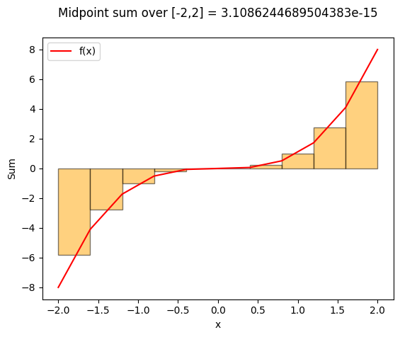

```python
riemann_sums(part12, -2, 2, 10, "mid", 0, 1)
```

- b. Repeat part (a) using left endpoint Riemann sums. Are the results still zero? Can you explain the difference, if any, between these two results?

```
Left endpoint Riemann sum over interval [-2,2] = -3.200000000000001
```

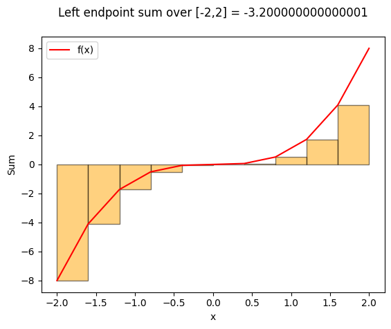

```python
riemann_sums(part12, -2, 2, 10, "left", 0, 1)
```

We are getting a negative, non-zero sum for the same function when calculating the left endpoint Riemann sum.

We can explain this visually, in that the boxes above do not appear as if they will cancel each other out across the interval. In the midpoint Riemann calculation, the "negative" boxes have a corresponding "positive" box with equivalent value, essentially canceling each other out.

However, because of how the left-endpoint calculation starts at the beginning of the interval, the sums for the negative side will be larger than the sums for the positive side for our function H(z)=z^3.

### Activity #4

Modify RIEMANN again with either the Trapezoid rule or the Simpsons Rule, section 11.6 What are the advantages of these methods?

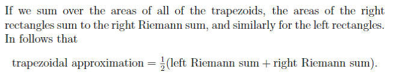

Since we configured our riemann_sums() function to pass its resulting sum if 'pass_values' is set to 2, we can leverage that function to create a trapezoidal approximation of the Riemann sum:

```python
def trapezoid_sum(func, a, b, num_steps):
        import matplotlib.pyplot as plt
        import numpy as np
        sum_left = riemann_sums(func, a, b, num_steps, "left", 0, 0, 2)
        sum_right = riemann_sums(func, a, b, num_steps, "right", 0, 0, 2)

        trap_sum = (sum_left + sum_right)/2
        print(f"Trapezoidal Riemann sum over interval [{a},{b}] = {trap_sum}\n")
        return
```

Let's demonstrate this with the same sample function we calculated earlier:

```python
def func(x):
    import math
    return math.sqrt(1 + x**3)

trapezoid_sum(func, 1, 3, 100)
```

```
Trapezoidal Riemann sum over interval [1,3] = 6.230009074384814
```

We can also do the same with Simpson's Rule which is given to us as:

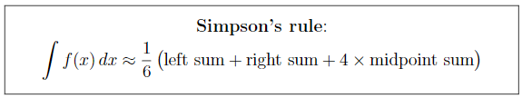

```python
def simpsons_rule(func, a, b, num_steps):
        import matplotlib.pyplot as plt
        import numpy as np
        sum_left = riemann_sums(func, a, b, num_steps, "left", 0, 0, 2)
        sum_mid = riemann_sums(func, a, b, num_steps, "mid", 0, 0, 2)
        sum_right= riemann_sums(func, a, b, num_steps, "right", 0, 0, 2)

        simpson_sum = (sum_left + sum_right + 4 * sum_mid)/6
        print(f"Simpson's Rule Riemann sum over interval [{a},{b}] = {simpson_sum}\n")
        return
```

```python
def func(x):
    import math
    return math.sqrt(1 + x**3)

simpsons_rule(func, 1, 3, 100)
```

```
Simpson's Rule Riemann sum over interval [1,3] = 6.229959387925201
```

Let's compare this with our endpoint approximations:

```python
riemann_sums(func, 1, 3, 100, "left")
riemann_sums(func, 1, 3, 100, "mid")
riemann_sums(func, 1, 3, 100, "right")
```

```
Left endpoint Riemann sum over interval [1,3] = 6.191236183787253

Midpoint Riemann sum over interval [1,3] = 6.229934544695395

Right endpoint Riemann sum over interval [1,3] = 6.268781964982374
```

As we can see, the Simpson's Rule Riemann sum approximation is almost equivalent to the Midpoint Riemann sum, which we determined earlier to be extremely efficient. The Trapezoidal Riemann sum approximation is also extremely close to the midpoint Riemann sum approximation.

The advantage to these methods is that they are able to account for possible errors which leads to a better approximation.

- The trapezoidal method is more accurate because the trapezoidal area that we evaluate for each subinterval is a better representation of f(x) than either of the left or right endpoint approximations. The trapezoidal approximation is inferior in accuracy to the midpoint Riemann sum which has less error overall (from p. 755).
- The main advantage of the Simpson's rule approximation is that it combines both trapezoidal and the midpoint approximations, which are both excellent in their own right, to arrive at a Riemann sum that has less error overall.